# Sliding-Window Investment Analysis

George Fisher

2016-05-09

# Scenario

We are facing retirement, having to live off a lump sum we have invested. How much can we withdraw each year adjusted for inflation?

## Parameters

```
* we are 65 years old
* we expect to live for 30 years
* we expect 2.5% annual inflation
* we expect to pay brokerage fees of 1.25%
```

```r
# function-specific parameters
library(sp500SlidingWindow)
window_width <- 30           # life expectancy
annual_fee   <- 0.0125       # brokerage fees
output_path  <- paste0(tempdir(), "/")

# analysis-specific parameters
current_age        <- 65            # starting age
annual_inflation   <- 0.025         # annual inflation
initial_investment <- 2000000       # our nest egg

# withdraw this much each year
withdrawal_percent <- 0.03171
initial_withdrawal <- initial_investment * withdrawal_percent
```

## Investment vector

We retire with this much money to live on for the rest of our ‘window_width’-year life

```r
investment_vector <- c(initial_investment,
                       rep(0,window_width-1))

fmt(investment_vector)
```

```
#>  [1] "2,000,000" "        0" "        0" "        0" "        0"
#>  [6] "        0" "        0" "        0" "        0" "        0"
#> [11] "        0" "        0" "        0" "        0" "        0"
#> [16] "        0" "        0" "        0" "        0" "        0"
#> [21] "        0" "        0" "        0" "        0" "        0"
#> [26] "        0" "        0" "        0" "        0" "        0"
```

## Withdrawal vector

We hope to spend the initial_withdrawal adjusted for inflation each year

```r
withdrawal_vector <- sapply(0:(window_width-1), function(i) {
    return(initial_withdrawal * (1 + annual_inflation)**i)
})

# total amount we hope to withdraw over the whole period
total_hoped_for_wdr <- sum(withdrawal_vector)
fmt(total_hoped_for_wdr)
```

```
#> [1] "2,784,309"
```

```r
# year-by-year hoped-for withdrawals
fmt(withdrawal_vector)
```

```
#>  [1] " 63,420" " 65,006" " 66,631" " 68,296" " 70,004" " 71,754" " 73,548"
#>  [8] " 75,386" " 77,271" " 79,203" " 81,183" " 83,213" " 85,293" " 87,425"
#> [15] " 89,611" " 91,851" " 94,147" " 96,501" " 98,914" "101,386" "103,921"
#> [22] "106,519" "109,182" "111,912" "114,709" "117,577" "120,517" "123,529"
#> [29] "126,618" "129,783"
```

# Sliding Window Analysis

The idea of sliding-window analysis is to ask how a certain set of annual investments and withdrawals would perform in each of the periods of a certain width of the stock market.

We are simulating a brokerage cash account so the balance can never go below zero. If the withdrawal vector calls for an amount greater than the current balance, the remaining balance is withdrawn and the balance is set to zero.

The analysis invests the lump sum at the beginning of each window and tracks the effect of the stock market on that investment, making inflation-adjusted withdrawals each year. The critical question is whether the investor will run out of money.

## Uninvested results

If we do not invest the lump sum but simply spend it down, what will be the result?

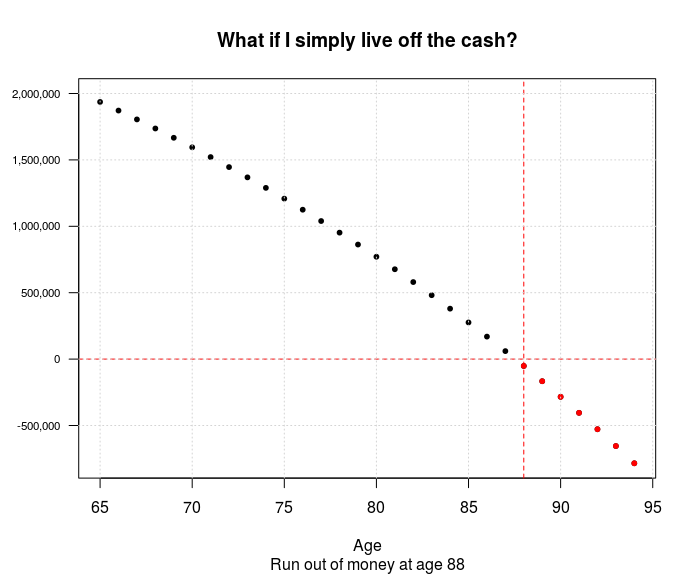

```r
remaining_amt    <- initial_investment
ages             <- current_age:(window_width+current_age-1)
remaining_amount <- sapply(1:window_width, function(i) {
    remaining_amt <<- remaining_amt - withdrawal_vector[i]
    return(remaining_amt)
})

# test if we go below zero
if (length(which(remaining_amount<=0))) {
    # goes below zero
    plot_points = TRUE
    busted_age <- current_age+which(remaining_amount<=0)[1]-1
    sub = paste0("Run out of money at age ", busted_age)
} else {
    # does not go below zero
    plot_points = FALSE
    sub="Starting amount covers withdrawals without investment"
}

ylim <- c(min(min(remaining_amount, 0)), initial_investment)
plot(ages, remaining_amount, pch=20,
     xlab="Age", ylab=NA, yaxt="n", ylim=ylim,
     main="What if I simply live off the cash?",
     sub=sub)
if (plot_points) {
    points(which(remaining_amount<=0)+current_age-1,
           remaining_amount[which(remaining_amount<=0)], col="red", pch=20)
    abline(v=busted_age, col="red", lty=2)
    abline(h=0, col="red", lty=2)
}

axis(2, las=2, at=axTicks(2), labels=fmt(axTicks(2)), cex.axis=0.72)
grid()
```

# Sliding Window Analysis

```r
window_df <- sp500SlidingWindow(investment_vector,
                                withdrawal_vector,
                                window_width = window_width,
                                annual_fee   = annual_fee,
                                output_path  = output_path)

#knitr::kable(window_df)
```

#### Number of failed periods 1; 97% percent success

## How are the results distributed?

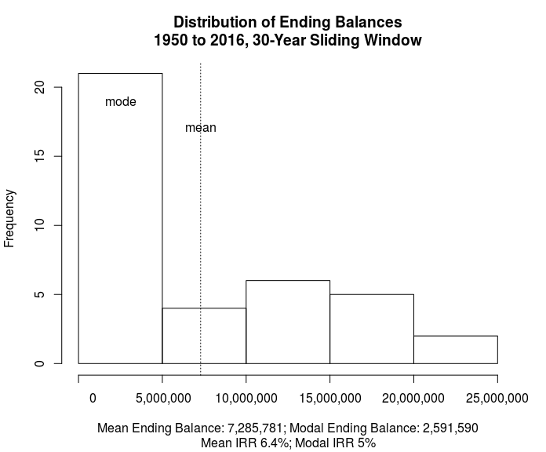

```r
plot_ending_bal_distribution(window_df, NULL, window_width)
```

## Worst Period

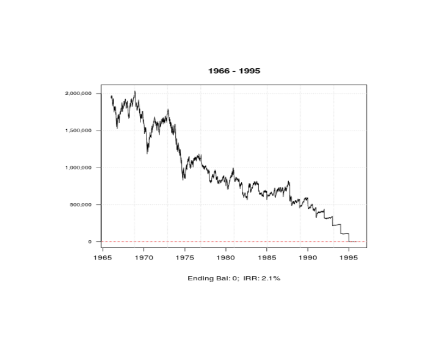

```r
library(png)
worst_period <- which.min(window_df$wdr)

worst_year_path <- paste0(output_path,
                          window_df$start_year[worst_period], "-",
                          window_df$end_year[worst_period], ".png")
pp <- readPNG(worst_year_path, native = TRUE, info = TRUE)
plot(0:1, 0:1, type="n", ann=FALSE, axes=FALSE)
rasterImage(pp, 0, 0, 1, 1)
```

## Best Period

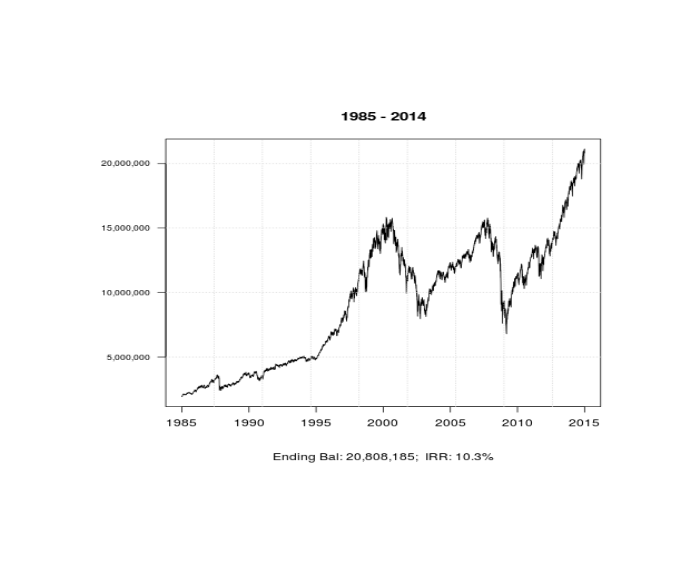

```r
best_period  <- which.max(window_df$ending_bal)

best_year_path <- paste0(output_path,
                          window_df$start_year[best_period], "-",
                          window_df$end_year[best_period], ".png")
pp <- readPNG(best_year_path, native = TRUE, info = TRUE)
plot(0:1, 0:1, type="n", ann=FALSE, axes=FALSE)
rasterImage(pp, 0, 0, 1, 1)
```

## Modal (Most-Likely) Period

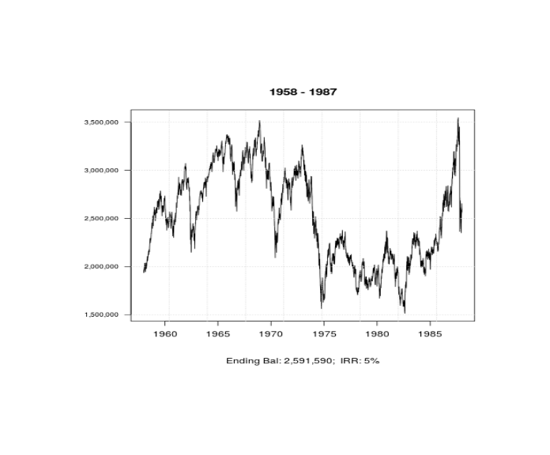

```r
bal_hist_obj    <- hist(window_df$ending_bal, plot=FALSE)
mod_end_bal     <- bal_hist_obj$mids[which.max(bal_hist_obj$counts)]
mod_window_idx  <- which.min(abs(window_df$ending_bal - mod_end_bal))
closest_mod_bal <- window_df$ending_bal[mod_window_idx]

mode_year_path <- paste0(output_path,
                          window_df$start_year[mod_window_idx], "-",
                          window_df$end_year[mod_window_idx], ".png")
pp <- readPNG(mode_year_path, native = TRUE, info = TRUE)
plot(0:1, 0:1, type="n", ann=FALSE, axes=FALSE)
rasterImage(pp, 0, 0, 1, 1)
```